# M-Estimators for Robust Linear Modeling

```python
%matplotlib inline

from __future__ import print_function
from statsmodels.compat import lmap
import numpy as np
from scipy import stats
import matplotlib.pyplot as plt

import statsmodels.api as sm
```

- An M-estimator minimizes the function

$$Q(e_i, \rho) = \sum_i~\rho \left (\frac{e_i}{s}\right )$$

where $\rho$ is a symmetric function of the residuals

- The effect of $\rho$ is to reduce the influence of outliers
- $s$ is an estimate of scale.
- The robust estimates $\hat{\beta}$ are computed by the iteratively re-weighted least squares algorithm
- We have several choices available for the weighting functions to be used

```python
norms = sm.robust.norms
```

```python
def plot_weights(support, weights_func, xlabels, xticks):
    fig = plt.figure(figsize=(12,8))
    ax = fig.add_subplot(111)
    ax.plot(support, weights_func(support))
    ax.set_xticks(xticks)
    ax.set_xticklabels(xlabels, fontsize=16)
    ax.set_ylim(-.1, 1.1)
    return ax
```

### Andrew's Wave

```python
help(norms.AndrewWave.weights)
```

```
Help on function weights in module statsmodels.robust.norms:

weights(self, z)
    Andrew's wave weighting function for the IRLS algorithm

    The psi function scaled by z

    Parameters
    ----------
    z : array-like
        1d array

    Returns
    -------
    weights : array
        weights(z) = sin(z/a)/(z/a)     for \|z\| <= a*pi

        weights(z) = 0                  for \|z\| > a*pi
```

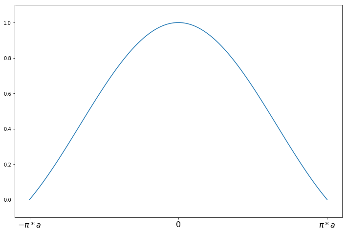

```python
a = 1.339
support = np.linspace(-np.pi*a, np.pi*a, 100)
andrew = norms.AndrewWave(a=a)
plot_weights(support, andrew.weights, ['$-\pi*a$', '0', '$\pi*a$'], [-np.pi*a, 0, np.pi*a]);
```

### Hampel's 17A

```python
help(norms.Hampel.weights)
```

```
Help on function weights in module statsmodels.robust.norms:

weights(self, z)
    Hampel weighting function for the IRLS algorithm

    The psi function scaled by z

    Parameters
    ----------
    z : array-like
        1d array

    Returns
    -------
    weights : array
        weights(z) = 1                            for \|z\| <= a

        weights(z) = a/\|z\|                        for a < \|z\| <= b

        weights(z) = a*(c - \|z\|)/(\|z\|*(c-b))      for b < \|z\| <= c

        weights(z) = 0                            for \|z\| > c
```

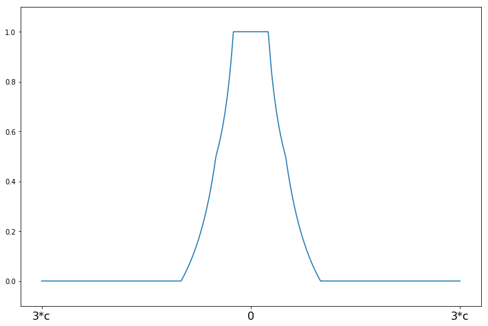

```python
c = 8
support = np.linspace(-3*c, 3*c, 1000)
hampel = norms.Hampel(a=2., b=4., c=c)
plot_weights(support, hampel.weights, ['3*c', '0', '3*c'], [-3*c, 0, 3*c]);
```

### Huber's t

```python
help(norms.HuberT.weights)
```

```
Help on function weights in module statsmodels.robust.norms:

weights(self, z)
    Huber's t weighting function for the IRLS algorithm

    The psi function scaled by z

    Parameters
    ----------
    z : array-like
        1d array

    Returns
    -------
    weights : array
        weights(z) = 1          for \|z\| <= t

        weights(z) = t/\|z\|      for \|z\| > t
```

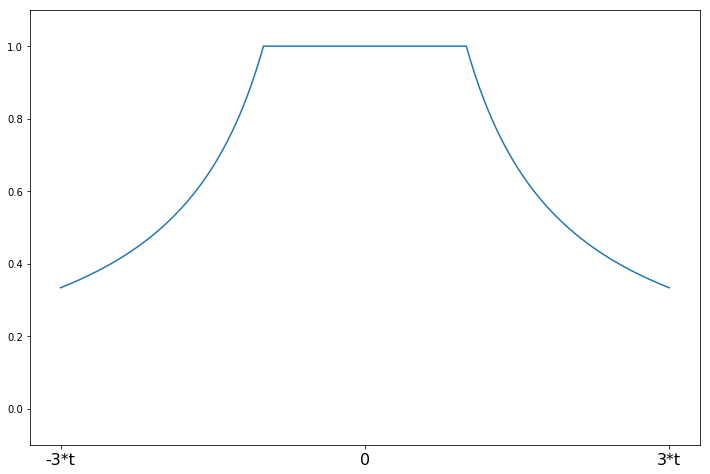

```python
t = 1.345
support = np.linspace(-3*t, 3*t, 1000)
huber = norms.HuberT(t=t)
plot_weights(support, huber.weights, ['-3*t', '0', '3*t'], [-3*t, 0, 3*t]);
```

### Least Squares

```python
help(norms.LeastSquares.weights)
```

```
Help on function weights in module statsmodels.robust.norms:

weights(self, z)
    The least squares estimator weighting function for the IRLS algorithm.

    The psi function scaled by the input z

    Parameters
    ----------
    z : array-like
        1d array

    Returns
    -------
    weights : array
        weights(z) = np.ones(z.shape)
```

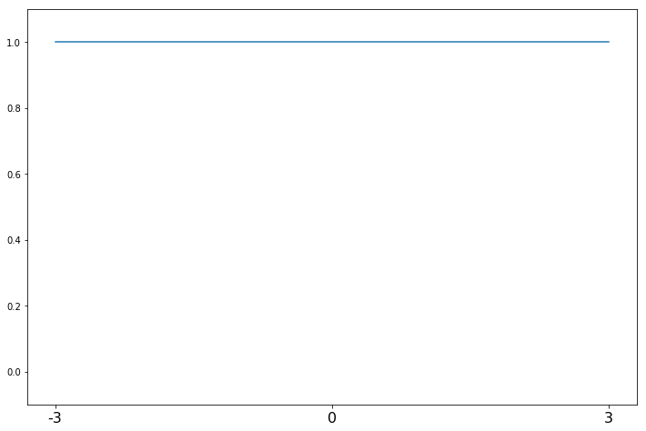

```python
support = np.linspace(-3, 3, 1000)
lst_sq = norms.LeastSquares()
plot_weights(support, lst_sq.weights, ['-3', '0', '3'], [-3, 0, 3]);
```

### Ramsay's Ea

```python
help(norms.RamsayE.weights)
```

```
Help on function weights in module statsmodels.robust.norms:

weights(self, z)
    Ramsay's Ea weighting function for the IRLS algorithm

    The psi function scaled by z

    Parameters
    ----------
    z : array-like
        1d array

    Returns
    -------
    weights : array
        weights(z) = exp(-a*\|z\|)
```

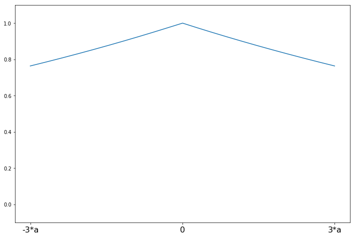

```python
a = .3
support = np.linspace(-3*a, 3*a, 1000)
ramsay = norms.RamsayE(a=a)
plot_weights(support, ramsay.weights, ['-3*a', '0', '3*a'], [-3*a, 0, 3*a]);
```

### Trimmed Mean

```python
help(norms.TrimmedMean.weights)
```

```
Help on function weights in module statsmodels.robust.norms:

weights(self, z)
    Least trimmed mean weighting function for the IRLS algorithm

    The psi function scaled by z

    Parameters
    ----------
    z : array-like
        1d array

    Returns
    -------
    weights : array
        weights(z) = 1             for \|z\| <= c

        weights(z) = 0             for \|z\| > c
```

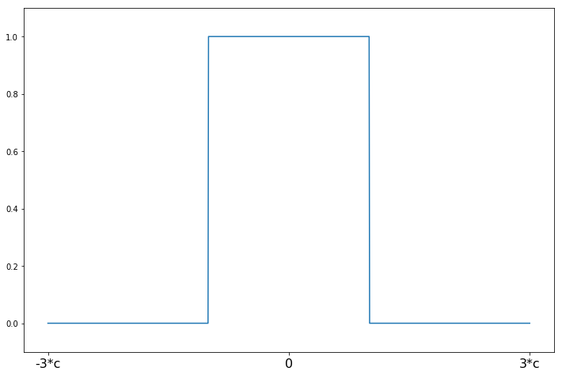

```python
c = 2
support = np.linspace(-3*c, 3*c, 1000)
trimmed = norms.TrimmedMean(c=c)
plot_weights(support, trimmed.weights, ['-3*c', '0', '3*c'], [-3*c, 0, 3*c]);
```

### Tukey's Biweight

```python
help(norms.TukeyBiweight.weights)
```

```
Help on function weights in module statsmodels.robust.norms:

weights(self, z)
    Tukey's biweight weighting function for the IRLS algorithm

    The psi function scaled by z

    Parameters
    ----------
    z : array-like
        1d array

    Returns
    -------
    weights : array
        psi(z) = (1 - (z/c)**2)**2          for \|z\| <= R

        psi(z) = 0                          for \|z\| > R
```

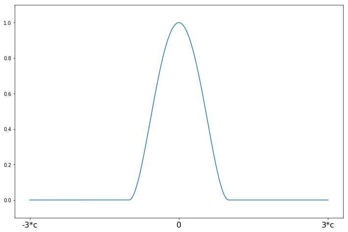

```python
c = 4.685
support = np.linspace(-3*c, 3*c, 1000)
tukey = norms.TukeyBiweight(c=c)
plot_weights(support, tukey.weights, ['-3*c', '0', '3*c'], [-3*c, 0, 3*c]);
```

### Scale Estimators

- Robust estimates of the location

```python
x = np.array([1, 2, 3, 4, 500])
```

- The mean is not a robust estimator of location

```python
x.mean()
```

```
102.0
```

- The median, on the other hand, is a robust estimator with a breakdown point of 50%

```python
np.median(x)
```

```
3.0
```

- Analagously for the scale
- The standard deviation is not robust

```python
x.std()
```

```
199.00251254695254
```

Median Absolute Deviation

$$ median_i |X_i - median_j(X_j)|) $$

Standardized Median Absolute Deviation is a consistent estimator for $\hat{\sigma}$

$$\hat{\sigma}=K \cdot MAD$$

where $K$ depends on the distribution. For the normal distribution for example,

```python
stats.norm.ppf(.75)
```

```
0.67448975019608171
```

```python
print(x)
```

```
[  1   2   3   4 500]
```

```python
sm.robust.scale.mad(x)
```

```
1.482602218505602
```

```python
np.array([1,2,3,4,5.]).std()
```

```
1.4142135623730951
```

- The default for Robust Linear Models is MAD
- another popular choice is Huber's proposal 2

```python
np.random.seed(12345)
fat_tails = stats.t(6).rvs(40)
```

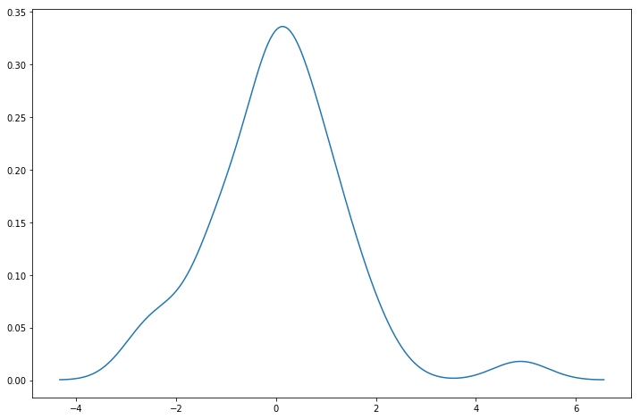

```python
kde = sm.nonparametric.KDEUnivariate(fat_tails)
kde.fit()
fig = plt.figure(figsize=(12,8))
ax = fig.add_subplot(111)
ax.plot(kde.support, kde.density);
```

```python
print(fat_tails.mean(), fat_tails.std())
```

```
0.0688231044811 1.34716332297
```

```python
print(stats.norm.fit(fat_tails))
```

```
(0.068823104481087499, 1.3471633229698652)
```

```python
print(stats.t.fit(fat_tails, f0=6))
```

```
(6, 0.039009187170278181, 1.0564230978488927)
```

```python
huber = sm.robust.scale.Huber()
loc, scale = huber(fat_tails)
print(loc, scale)
```

```
0.04048984333271795 1.1557140047569665
```

```python
sm.robust.mad(fat_tails)
```

```
1.1153350011654151
```

```python
sm.robust.mad(fat_tails, c=stats.t(6).ppf(.75))
```

```
1.0483916565928972
```

```python
sm.robust.scale.mad(fat_tails)
```

```
1.1153350011654151
```

### Duncan's Occupational Prestige data - M-estimation for outliers

```python
from statsmodels.graphics.api import abline_plot
from statsmodels.formula.api import ols, rlm
```

```python
prestige = sm.datasets.get_rdataset("Duncan", "car", cache=True).data
```

```python
print(prestige.head(10))
```

```
            type  income  education  prestige
accountant  prof      62         86        82
pilot       prof      72         76        83
architect   prof      75         92        90
author      prof      55         90        76
chemist     prof      64         86        90
minister    prof      21         84        87
professor   prof      64         93        93
dentist     prof      80        100        90
reporter      wc      67         87        52
engineer    prof      72         86        88
```

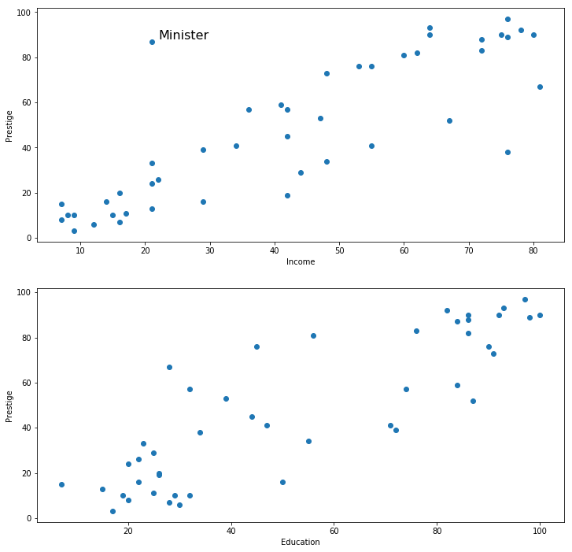

```python
fig = plt.figure(figsize=(12,12))
ax1 = fig.add_subplot(211, xlabel='Income', ylabel='Prestige')
ax1.scatter(prestige.income, prestige.prestige)
xy_outlier = prestige.ix['minister'][['income','prestige']]
ax1.annotate('Minister', xy_outlier, xy_outlier+1, fontsize=16)
ax2 = fig.add_subplot(212, xlabel='Education',
                           ylabel='Prestige')
ax2.scatter(prestige.education, prestige.prestige);
```

```python
ols_model = ols('prestige ~ income + education', prestige).fit()
print(ols_model.summary())
```

```
                            OLS Regression Results
==============================================================================
Dep. Variable:               prestige   R-squared:                       0.828
Model:                            OLS   Adj. R-squared:                  0.820
Method:                 Least Squares   F-statistic:                     101.2
Date:                Tue, 28 Feb 2017   Prob (F-statistic):           8.65e-17
Time:                        21:34:18   Log-Likelihood:                -178.98
No. Observations:                  45   AIC:                             364.0
Df Residuals:                      42   BIC:                             369.4
Df Model:                           2
Covariance Type:            nonrobust
==============================================================================
                 coef    std err          t      P>|t|      [0.025      0.975]
------------------------------------------------------------------------------
Intercept     -6.0647      4.272     -1.420      0.163     -14.686       2.556
income         0.5987      0.120      5.003      0.000       0.357       0.840
education      0.5458      0.098      5.555      0.000       0.348       0.744
==============================================================================
Omnibus:                        1.279   Durbin-Watson:                   1.458
Prob(Omnibus):                  0.528   Jarque-Bera (JB):                0.520
Skew:                           0.155   Prob(JB):                        0.771
Kurtosis:                       3.426   Cond. No.                         163.
==============================================================================

Warnings:
[1] Standard Errors assume that the covariance matrix of the errors is correctly specified.
```

```python
infl = ols_model.get_influence()
student = infl.summary_frame()['student_resid']
print(student)
```

```
accountant    0.303900
pilot         0.340920
architect     0.072256
author        0.000711
chemist       0.826578
                ...
soda.clerk   -0.883095
watchman     -0.513502
janitor      -0.079890
policeman     0.078847
waiter       -0.475972
Name: student_resid, dtype: float64
```

```python
print(student.ix[np.abs(student) > 2])
```

```
minister      3.134519
reporter     -2.397022
contractor    2.043805
Name: student_resid, dtype: float64
```

```python
print(infl.summary_frame().ix['minister'])
```

```
dfb_Intercept      0.144937
dfb_income        -1.220939
dfb_education      1.263019
cooks_d            0.566380
dffits             1.433935
dffits_internal    1.303510
hat_diag           0.173058
standard_resid     2.849416
student_resid      3.134519
Name: minister, dtype: float64
```

```python
sidak = ols_model.outlier_test('sidak')
sidak.sort('unadj_p', inplace=True)
print(sidak)
```

```
                 student_resid   unadj_p  sidak(p)
minister              3.134519  0.003177  0.133421
reporter             -2.397022  0.021170  0.618213
contractor            2.043805  0.047433  0.887721
insurance.agent      -1.930919  0.060428  0.939485
machinist             1.887047  0.066248  0.954247
...                        ...       ...       ...
policeman             0.078847  0.937538  1.000000
architect             0.072256  0.942750  1.000000
teacher               0.050510  0.959961  1.000000
taxi.driver           0.023322  0.981507  1.000000
author                0.000711  0.999436  1.000000

[45 rows x 3 columns]
```

```python
fdr = ols_model.outlier_test('fdr_bh')
fdr.sort('unadj_p', inplace=True)
print(fdr)
```

```
                 student_resid   unadj_p  fdr_bh(p)
minister              3.134519  0.003177   0.142974
reporter             -2.397022  0.021170   0.476332
contractor            2.043805  0.047433   0.596233
insurance.agent      -1.930919  0.060428   0.596233
machinist             1.887047  0.066248   0.596233
...                        ...       ...        ...
policeman             0.078847  0.937538   0.999436
architect             0.072256  0.942750   0.999436
teacher               0.050510  0.959961   0.999436
taxi.driver           0.023322  0.981507   0.999436
author                0.000711  0.999436   0.999436

[45 rows x 3 columns]
```

```python
rlm_model = rlm('prestige ~ income + education', prestige).fit()
print(rlm_model.summary())
```

```
                    Robust linear Model Regression Results
==============================================================================
Dep. Variable:               prestige   No. Observations:                   45
Model:                            RLM   Df Residuals:                       42
Method:                          IRLS   Df Model:                            2
Norm:                          HuberT
Scale Est.:                       mad
Cov Type:                          H1
Date:                Tue, 28 Feb 2017
Time:                        21:34:18
No. Iterations:                    18
==============================================================================
                 coef    std err          z      P>|z|      [0.025      0.975]
------------------------------------------------------------------------------
Intercept     -7.1107      3.879     -1.833      0.067     -14.713       0.492
income         0.7015      0.109      6.456      0.000       0.489       0.914
education      0.4854      0.089      5.441      0.000       0.311       0.660
==============================================================================

If the model instance has been used for another fit with different fit
parameters, then the fit options might not be the correct ones anymore .
```

```python
print(rlm_model.weights)
```

```
accountant    1.0
pilot         1.0
architect     1.0
author        1.0
chemist       1.0
             ...
soda.clerk    1.0
watchman      1.0
janitor       1.0
policeman     1.0
waiter        1.0
dtype: float64
```

### Hertzprung Russell data for Star Cluster CYG 0B1 - Leverage Points

- Data is on the luminosity and temperature of 47 stars in the direction of Cygnus.

```python
dta = sm.datasets.get_rdataset("starsCYG", "robustbase", cache=True).data
```

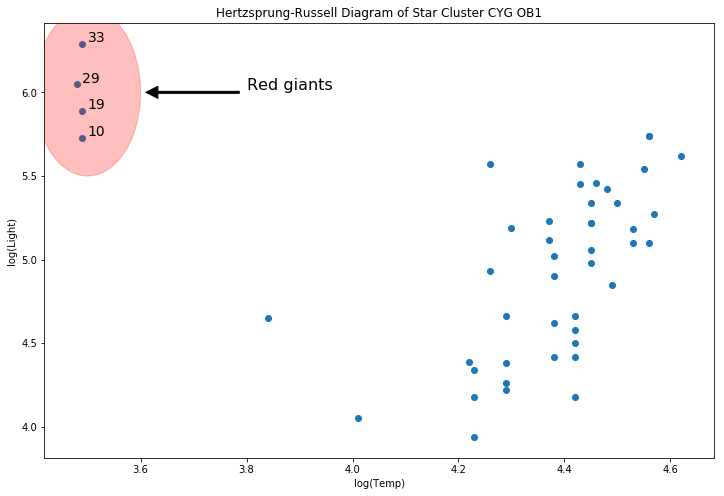

```python
from matplotlib.patches import Ellipse
fig = plt.figure(figsize=(12,8))
ax = fig.add_subplot(111, xlabel='log(Temp)', ylabel='log(Light)', title='Hertzsprung-Russell Diagram of Star Cluster CYG OB1')
ax.scatter(*dta.values.T)
# highlight outliers
e = Ellipse((3.5, 6), .2, 1, alpha=.25, color='r')
ax.add_patch(e);
ax.annotate('Red giants', xy=(3.6, 6), xytext=(3.8, 6),
            arrowprops=dict(facecolor='black', shrink=0.05, width=2),
            horizontalalignment='left', verticalalignment='bottom',
            clip_on=True, # clip to the axes bounding box
            fontsize=16,
     )
# annotate these with their index
for i,row in dta.ix[dta['log.Te'] < 3.8].iterrows():
    ax.annotate(i, row, row + .01, fontsize=14)
xlim, ylim = ax.get_xlim(), ax.get_ylim()
```

```python
from IPython.display import Image
Image(filename='star_diagram.png')
```

[output not shown]

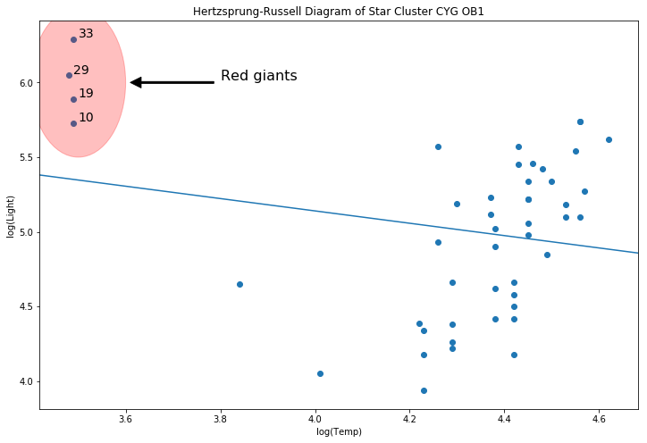

```python
y = dta['log.light']
X = sm.add_constant(dta['log.Te'], prepend=True)
ols_model = sm.OLS(y, X).fit()
abline_plot(model_results=ols_model, ax=ax)
```

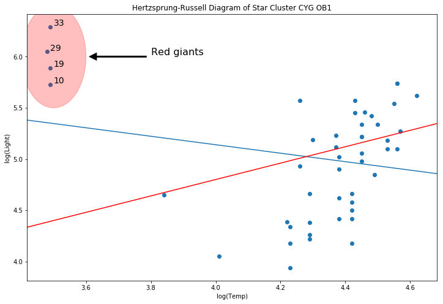

```python
rlm_mod = sm.RLM(y, X, sm.robust.norms.TrimmedMean(.5)).fit()
abline_plot(model_results=rlm_mod, ax=ax, color='red')
```

- Why? Because M-estimators are not robust to leverage points.

```python
infl = ols_model.get_influence()
```

```python
h_bar = 2*(ols_model.df_model + 1 )/ols_model.nobs
hat_diag = infl.summary_frame()['hat_diag']
hat_diag.ix[hat_diag > h_bar]
```

```
10    0.194103
19    0.194103
29    0.198344
33    0.194103
Name: hat_diag, dtype: float64
```

```python
sidak2 = ols_model.outlier_test('sidak')
sidak2.sort('unadj_p', inplace=True)
print(sidak2)
```

```
    student_resid   unadj_p  sidak(p)
16      -2.049393  0.046415  0.892872
13      -2.035329  0.047868  0.900286
33       1.905847  0.063216  0.953543
18      -1.575505  0.122304  0.997826
1        1.522185  0.135118  0.998911
..            ...       ...       ...
2       -0.182093  0.856346  1.000000
23      -0.156014  0.876736  1.000000
27      -0.147406  0.883485  1.000000
24       0.065195  0.948314  1.000000
45       0.045675  0.963776  1.000000

[47 rows x 3 columns]
```

```python
fdr2 = ols_model.outlier_test('fdr_bh')
fdr2.sort('unadj_p', inplace=True)
print(fdr2)
```

```
    student_resid   unadj_p  fdr_bh(p)
16      -2.049393  0.046415   0.764747
13      -2.035329  0.047868   0.764747
33       1.905847  0.063216   0.764747
18      -1.575505  0.122304   0.764747
1        1.522185  0.135118   0.764747
..            ...       ...        ...
2       -0.182093  0.856346   0.922751
23      -0.156014  0.876736   0.922751
27      -0.147406  0.883485   0.922751
24       0.065195  0.948314   0.963776
45       0.045675  0.963776   0.963776

[47 rows x 3 columns]
```

- Let's delete that line

```python
del ax.lines[-1]
```

```python
weights = np.ones(len(X))
weights[X[X['log.Te'] < 3.8].index.values - 1] = 0
wls_model = sm.WLS(y, X, weights=weights).fit()
abline_plot(model_results=wls_model, ax=ax, color='green')
```

[output not shown]

- MM estimators are good for this type of problem, unfortunately, we don't yet have these yet.
- It's being worked on, but it gives a good excuse to look at the R cell magics in the notebook.

```python
yy = y.values[:,None]
xx = X['log.Te'].values[:,None]
```

```python
%load_ext rpy2.ipython

%R library(robustbase)
%Rpush yy xx
%R mod <- lmrob(yy ~ xx);
%R params <- mod$coefficients;
%Rpull params
```

[output not shown]

```python
%R print(mod)
```

[output not shown]

```python
print(params)
```

[output not shown]

```python
abline_plot(intercept=params[0], slope=params[1], ax=ax, color='green')
```

[output not shown]

### Exercise: Breakdown points of M-estimator

```python
np.random.seed(12345)
nobs = 200
beta_true = np.array([3, 1, 2.5, 3, -4])
X = np.random.uniform(-20,20, size=(nobs, len(beta_true)-1))
# stack a constant in front
X = sm.add_constant(X, prepend=True) # np.c_[np.ones(nobs), X]
mc_iter = 500
contaminate = .25 # percentage of response variables to contaminate
```

```python
all_betas = []
for i in range(mc_iter):
    y = np.dot(X, beta_true) + np.random.normal(size=200)
    random_idx = np.random.randint(0, nobs, size=int(contaminate * nobs))
    y[random_idx] = np.random.uniform(-750, 750)
    beta_hat = sm.RLM(y, X).fit().params
    all_betas.append(beta_hat)
```

```python
all_betas = np.asarray(all_betas)
se_loss = lambda x : np.linalg.norm(x, ord=2)**2
se_beta = lmap(se_loss, all_betas - beta_true)
```

#### Squared error loss

```python
np.array(se_beta).mean()
```

```
0.44502948730686354
```

```python
all_betas.mean(0)
```

```
array([ 2.99711706,  0.99898147,  2.49909344,  2.99712918, -3.99626521])
```

```python
beta_true
```

```
array([ 3. ,  1. ,  2.5,  3. , -4. ])
```

```python
se_loss(all_betas.mean(0) - beta_true)
```

```
3.2360913286763295e-05
```